# Проект 3: Исследование рынка недвижимости Санкт-Петербурга и городов-спутников

#### Анализ факторов влияющих на цену квартир в центре

Для анализа влияния факторов используем функцию из пункта 4.4.1

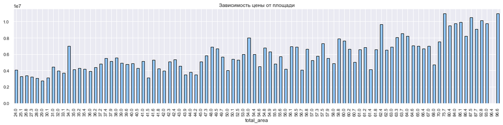

```python
impact_analysis(data_spb_center, 'total_area')
#Закомментил так как при обработке компьютер подвисает
```

**Вывод** Цена прямопропорционально зависит от площади квартиры

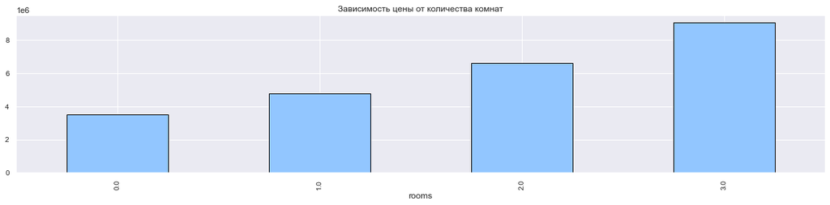

```python
impact_analysis(data_spb_center, 'rooms')
```

**Вывод** Чем больше комнат тем выше цена. Квартиры с большим (болше 3-6) числом комнат - сорее всего рассённые (выкуленные по частям) коммуналки

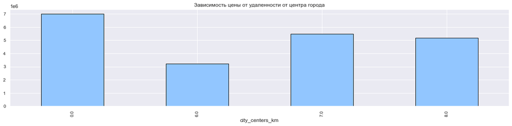

```python
impact_analysis(data_spb_center, 'city_centers_km')
```

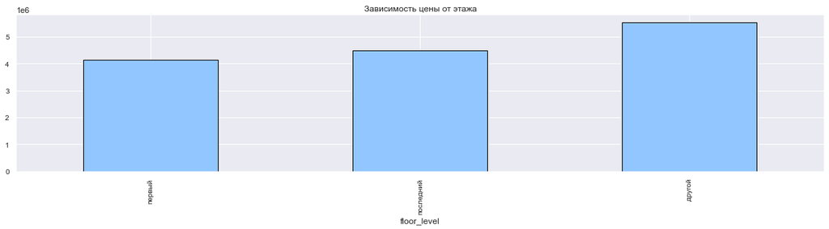

```python
impact_analysis(data_spb_center, 'floor_level')
```

**Вывод** Квартиры на первых этажах дешевле всего, далее следуют квартиры на последних этажах, дороже всего квартиры не на первом и не на втром этаже.

#### Зависимость цены от даты размещения

Для анализа влияния факторов используем функцию из пункта 4.4.6

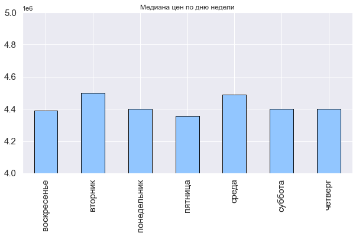

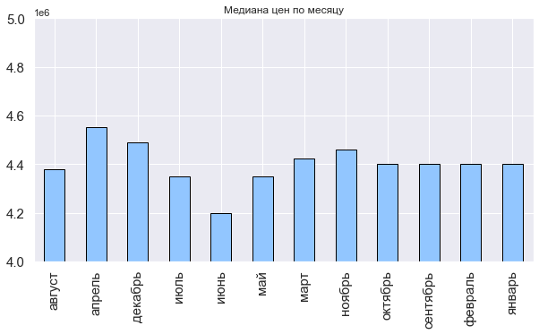

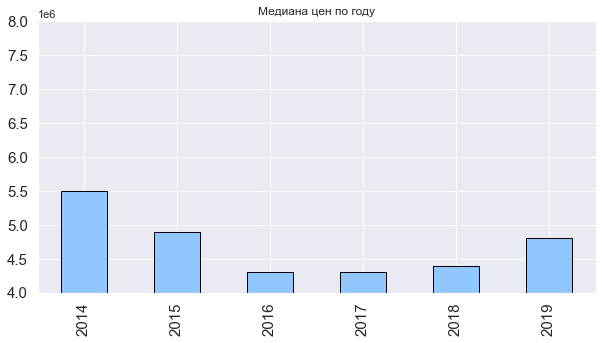

```python
# Масштаб графиков взятых от нуля не даст чётко увидить тенденции,  из предыдущего опыта знаем что цен ниже 4 млн нет
# увеличим масстаб каждого графика по вертикали,
# ограничим каждый график по оси Y  интервалом значений 4 - 5 млн руб. для дня недели и месяца и 4 - 8 млн руб. для года
placement_price(df=data_spb_center, ylims=[(4000000, 5000000), (4000000, 5000000), (4000000, 8000000)])
```

**Выводы:** В целом повторимся

1. цена от дня недели публикации практически никак не зависит. Но, средняя цена обьявлений опубликованных в будни чуть выше чем у опубликованных в конце рабочей недели и выходные.
2. зависимость цены от месяца публикации - самые сысокие цены у опубликованных в апреле, самые низкие - в июне.
3. зависимость цены от года публикации. Выделяется 2014 год - присоеденение крыма, санкции - население вкладывает деньги в ценные активы - недвижимость. Растёт спрос - растут цены. В 2015 году - ажиотаж постепенно утихает. В 2019 году - начало пандемии COVID-19, ралли на нефтяном рынке - растёт спрос на недвижимость. В 2020-2021 годах, если бы были данные, был бы скачёк - рынок дополнительно разогрела льготная ипотека.

#### Сопоставление влияние факторов на цену в целом по выборке и в центре города

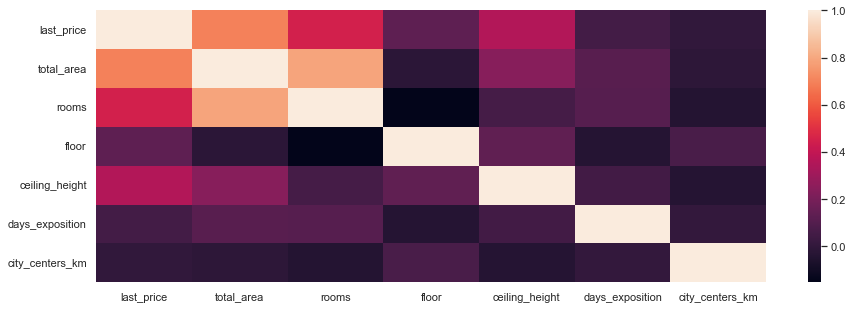

```python
#Построим тепловую карту корреляции признаков для всех наблюдений в базе
data_columns=data[['last_price', 'total_area', 'rooms', 'floor','ceiling_height', 'days_exposition', 'city_centers_km']]# Выбирем колонки
corr = data_columns.corr() #используем Pandas dataframe.corr() для нахождения попарной корреляции колонок
figsize=(5, 5)
sns.heatmap(corr,
            xticklabels=corr.columns.values,
            yticklabels=corr.columns.values)
```

**Выводы** в целом по выборке:

1. Самая сильная зависимость от общей площади квартиры.
2. На второй позиции количество комнат.
3. На третем - высота потолков.
4. Далее по влиянию - этаж и количество дней экспозиции.
5. Удаленность от центра оказывает наименьшее влияние

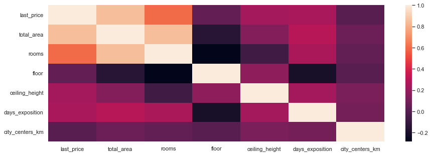

```python
#Построим тепловую карту корреляции признаков для объектов в центре Санкт-Петербурга
data_spb_center_columns=data_spb_center[['last_price', 'total_area', 'rooms', 'floor', 'ceiling_height', 'days_exposition', 'city_centers_km']]# Выбирем колонки
corr = data_spb_center_columns.corr() #используем Pandas dataframe.corr() для нахождения попарной корреляции колонок
figsize=(5, 5)
sns.heatmap(corr,
            xticklabels=corr.columns.values,
            yticklabels=corr.columns.values)
```

**Выводы** по выборке в центре Санкт-Петербурга:

1. Самая сильная зависимость от общей площади квартиры.
2. На второй позиции количество комнат.
3. На третей - этаж, высота потолков и количество дней экспозиции.
4. Самое меньшее влияние оказывает удаленность от центра.

## Чек-лист готовности проекта

Поставьте 'x' в выполненных пунктах. Далее нажмите Shift+Enter.

- [x] открыт файл
- [x] файлы изучены (выведены первые строки, метод `info()`)
- [x] определены пропущенные значения
- [x] заполнены пропущенные значения
- [x] есть пояснение, какие пропущенные значения обнаружены
- [x] изменены типы данных
- [x] есть пояснение, в каких столбцах изменены типы и почему
- [x] посчитано и добавлено в таблицу: цена квадратного метра
- [x] посчитано и добавлено в таблицу: день недели, месяц и год публикации объявления
- [x] посчитано и добавлено в таблицу: этаж квартиры; варианты — первый, последний, другой
- [x] посчитано и добавлено в таблицу: соотношение жилой и общей площади, а также отношение площади кухни к общей
- [x] изучены следующие параметры: площадь, цена, число комнат, высота потолков
- [x] построены гистограммы для каждого параметра
- [x] выполнено задание: «Изучите время продажи квартиры. Постройте гистограмму. Посчитайте среднее и медиану. Опишите, сколько обычно занимает продажа. Когда можно считать, что продажи прошли очень быстро, а когда необычно долго?»
- [x] выполнено задание: «Уберите редкие и выбивающиеся значения. Опишите, какие особенности обнаружили».
- [x] выполнено задание: «Какие факторы больше всего влияют на стоимость квартиры? Изучите, зависит ли цена от квадратного метра, числа комнат, этажа (первого или последнего), удалённости от центра. Также изучите зависимость от даты размещения: дня недели, месяца и года».
- [x] выполнено задание: «Выберите 10 населённых пунктов с наибольшим числом объявлений. Посчитайте среднюю цену квадратного метра в этих населённых пунктах. Выделите населённые пункты с самой высокой и низкой стоимостью жилья. Эти данные можно найти по имени в столбце `locality_name`».
- [x] выполнено задание: «Изучите предложения квартир: для каждой квартиры есть информация о расстоянии до центра. Выделите квартиры в Санкт-Петербурге (`locality_name`). Ваша задача — выяснить, какая область входит в центр. Создайте столбец с расстоянием до центра в километрах: округлите до целых значений. После этого посчитайте среднюю цену для каждого километра. Постройте график: он должен показывать, как цена зависит от удалённости от центра. Определите границу, где график сильно меняется — это и будет центральная зона».
- [x] выполнено задание: «Выделите сегмент квартир в центре. Проанализируйте эту территорию и изучите следующие параметры: площадь, цена, число комнат, высота потолков. Также выделите факторы, которые влияют на стоимость квартиры (число комнат, этаж, удалённость от центра, дата размещения объявления). Сделайте выводы. Отличаются ли они от общих выводов по всей базе?»
- [x] в каждом этапе есть выводы
- [x] есть общий вывод